# Model Fitting and Ancestral Character State Reconstruction

## Compare Results

Compare Model Fit using AIC

```r
Q
```

```
##       [,1]  [,2]
## [1,] -0.03  0.03
## [2,]  0.10 -0.10
```

```r
Recon_Q.Sim
```

```
##
## Fit
##       -lnL      AIC     AICc ntax
##  -119.0397 240.0793 240.0995  200
##
## Rates
##            1          2
## 1         NA 0.02258355
## 2 0.02258355         NA
##
## Arrived at a reliable solution
```

```r
Recon_Q.Asim
```

```
##
## Fit
##       -lnL      AIC     AICc ntax
##  -105.0284 214.0568 214.1177  200
##
## Rates
##            1          2
## 1         NA 0.03570026
## 2 0.09957736         NA
##
## Arrived at a reliable solution
```

```r
# delta AIC
Recon_Q.Sim$AIC-Recon_Q.Asim$AIC
```

```
## [1] 26.02251
```

## Home Excrcise

Try to code your own Likelihood function that calculates likelihood of a state pattern given (i) a tree, (ii) rate matrix with specified parameters, and (iii) a specified initial vector. It can be a simple Ln function that works specifically with small trees (3 taxa). Your toy algorithm should work like Felsentein’s pruning algorithm from Lecture 6. You may choose any states at tips (use binary characters for brevity).

Before, coding Ln function, simulate a tree and note the main data structures that store tree topology and branch lengths

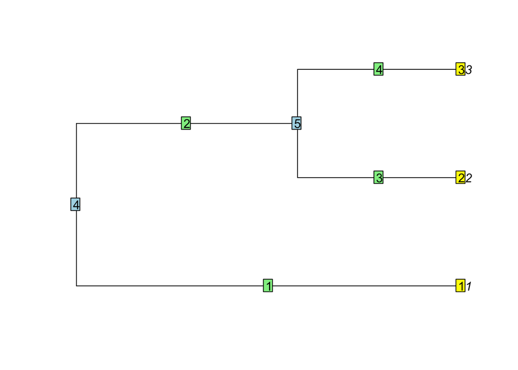

```r
set.seed(100)
tr<-pbtree(n=3, scale=1, b=1, d=0)
plot(tr)
nodelabels()
edgelabels()
tiplabels()
```

```r
# save tree file
library(ape)
write.tree(tr, file='3_taxon.tree')
```

You will need thee object for you Ln function *tr$edge* *tr$edge.length*

```r
# tree topologu
tr$edge
```

```
##      [,1] [,2]
## [1,]    4    1
## [2,]    4    5
## [3,]    5    2
## [4,]    5    3
```

```r
# branch lengths
tr$edge.length
```

```
## [1] 1.0000000 0.5740947 0.4259053 0.4259053
```